# R Notebook

# Does inaugurals become simpler?

# Step 0: check and install needed packages. Load the libraries and functions.

```r
packages.used <- c("rvest", "tibble", "qdap",
                 "gplots", "dplyr",
                "tm", "syuzhet", "factoextra",
                "beeswarm", "scales", "RColorBrewer",
                "RANN", "topicmodels")

# check packages that need to be installed.
packages.needed <- setdiff(packages.used,
                        intersect(installed.packages()[,1],
                                  packages.used))
# install additional packages
if(length(packages.needed)>0){
  install.packages(packages.needed, dependencies = TRUE)
}

# load packages
library("rvest")
library("qdap")
library("gplots")
library("ggplot2")
library("dplyr")
library("RColorBrewer")
library("koRpus")
```

This notebook was prepared with the following environmental settings.

```r
print(R.version)
```

```
##                _
## platform       x86_64-apple-darwin13.4.0
## arch           x86_64
## os             darwin13.4.0
## system         x86_64, darwin13.4.0
## status
## major          3
## minor          3.1
## year           2016
## month          06
## day            21
## svn rev        70800
## language       R
## version.string R version 3.3.1 (2016-06-21)
## nickname       Bug in Your Hair
```

# Step 1: Data harvest: scrap speech URLs from http://www.presidency.ucsb.edu/.

Following the example of [Jerid Francom](http://francojc.github.io/web-scraping-with-rvest/),we scrap the links of all inaugural addresses of past presidents.

```r
main.page <- read_html(x = "http://www.presidency.ucsb.edu/inaugurals.php")
urls <- main.page %>%
    html_nodes(".ver12 a") %>%
    html_attr("href")

links <- main.page %>%
    html_nodes(".ver12 a") %>%
    html_text()

out <- data.frame(links = links, urls = urls, stringsAsFactors = FALSE)
inaugural <- out[-nrow(out),]
```

# Step 2: Using speech metadata posted on http://www.presidency.ucsb.edu/, we prepared CSV data sets for the speeches we will scrap.

```r
inaug.cvs <- read.csv("../Data/inauglist.csv", stringsAsFactors = F)
addresses <- cbind(inaug.cvs, inaugural)
```

# Step 3: scrap the texts of speeches from the speech URLs.

We scrap the main text part of the transcript’s html page. For simple html pages of this kind, [Selectorgadget](http://selectorgadget.com/) is very convenient for identifying the html node that `rvest` can use to scrap its content. And we combine the scraped text to the previous CSV data sets.

```r
addresses$fulltext <- NULL
for(i in 1:nrow(addresses)){
  text <- read_html(addresses$urls[i]) %>%
    html_node(".displaytext") %>%
    html_text()
  addresses$fulltext[i] <- text
}
```

# Step 4: data analysis — length of sentences

We would like to see how the length of sentences in inaugural changes over the time. In order to measure it, we simply calculate the average length of sentences in each inaugurals.

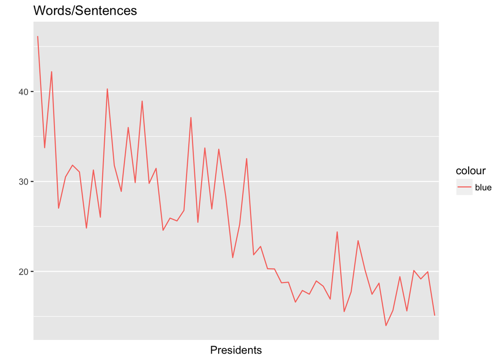

```r
addresses$sentences <-NULL
for(i in 1:nrow(addresses)){
  sent.len <- sent_detect(addresses$fulltext[i],
                          endmarks = c("?",".","!","|",";"))
  addresses$sentences[i] <- length(sent.len)
}
pre.names <- as.character(addresses$President)
ggplot() +
  geom_line(mapping = aes(x = c(1:58),
                          y = addresses$Words/addresses$sentences,
                          col = "blue"))+
            labs(title = "Words/Sentences", x = "Presidents", y = "")+
            scale_x_discrete(labels = pre.names)
```

From the graph above, we observe that the length of sentences gets shorter.

# Step 5: data analysis — lexical diversity

We have already known that the sentences get shorter. What about the lexical diversity? Lexical diversity is a measure of how many different words that are used in a text. In order to measure it, we use [MSTTR](http://www.let.rug.nl/suster/unpublished/wow_complexity.pdf) and follow the steps of [m.eik michalke](https://cran.r-project.org/web/packages/koRpus/vignettes/koRpus_vignette.pdf)

```r
tagged.inaug <- list(NULL)
for(i in 1:nrow(addresses)){
  tagged.inaug[[i]] <- tokenize(addresses$fulltext[i], format = "obj", lang = "en")
}
MSTTR.inaug <- NULL
for(i in 1:length(tagged.inaug)){
  MSTTR.inaug[i] <- MSTTR(tagged.inaug[[i]])@MSTTR$MSTTR
}
```

[output not shown]

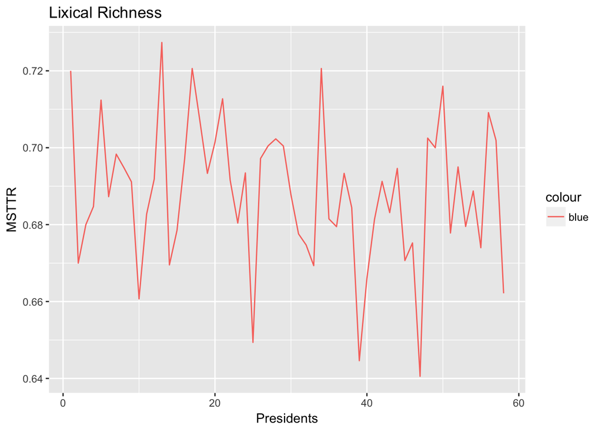

```r
ggplot() + geom_line(mapping = aes(x = c(1:58), y = MSTTR.inaug, col = "blue"))+
  labs(title = "Lixical Richness", x = "Presidents", y = "MSTTR")
```